# Assignment 4

Bhagyarathi Raman

2/18/2022

The ToyotaPrices dataset resides in the Dropbox Folder (/#lectures/# data) with an MS Excel file type as well as a CSV file type.

Download and Import the data into R Studio.

```r
#Empty the environment
rm(list=ls())
```

```r
ToyotaPrices <- read.csv("/Users/bhagyarathivivek/downloads/# data/ToyotaPrices/ToyotaPrices.csv")
```

Make sure you include the read file command in your source file.

Convert Tow_Bar and ABS to a factor with yes, no levels.

```r
ToyotaPrices$ABS=factor(ToyotaPrices$ABS)
levels(ToyotaPrices)=c("NO", "YES")
ToyotaPrices$Tow_Bar=factor(ToyotaPrices$Tow_Bar)
levels(ToyotaPrices$Tow_Bar)= c("NO","YES")
```

If KM is less than 500, convert the value to missing.

```r
ToyotaPrices$KM[ToyotaPrices$KM<500]=NA
summary(ToyotaPrices)
```

```
##        Id             Price         Age_08_04       Mfg_Month
##  Min.   :   1.0   Min.   : 4350   Min.   : 1.00   Min.   : 1.000
##  1st Qu.: 361.8   1st Qu.: 8450   1st Qu.:44.00   1st Qu.: 3.000
##  Median : 721.5   Median : 9900   Median :61.00   Median : 5.000
##  Mean   : 721.6   Mean   :10731   Mean   :55.95   Mean   : 5.549
##  3rd Qu.:1081.2   3rd Qu.:11950   3rd Qu.:70.00   3rd Qu.: 8.000
##  Max.   :1442.0   Max.   :32500   Max.   :80.00   Max.   :12.000
##
##     Mfg_Year          KM               HP          Automatic
##  Min.   :1998   Min.   :  1500   Min.   : 69.0   Min.   :0.00000
##  1st Qu.:1998   1st Qu.: 43426   1st Qu.: 90.0   1st Qu.:0.00000
##  Median :1999   Median : 63792   Median :110.0   Median :0.00000
##  Mean   :2000   Mean   : 69062   Mean   :101.5   Mean   :0.05571
##  3rd Qu.:2001   3rd Qu.: 87358   3rd Qu.:110.0   3rd Qu.:0.00000
##  Max.   :2004   Max.   :243000   Max.   :192.0   Max.   :1.00000
##                 NA's   :11
##        cc            Doors         Cylinders     Gears       Quarterly_Tax
##  Min.   : 1300   Min.   :2.000   Min.   :4   Min.   :3.000   Min.   : 19.00
##  1st Qu.: 1400   1st Qu.:3.000   1st Qu.:4   1st Qu.:5.000   1st Qu.: 69.00
##  Median : 1600   Median :4.000   Median :4   Median :5.000   Median : 85.00
##  Mean   : 1577   Mean   :4.033   Mean   :4   Mean   :5.026   Mean   : 87.12
##  3rd Qu.: 1600   3rd Qu.:5.000   3rd Qu.:4   3rd Qu.:5.000   3rd Qu.: 85.00
##  Max.   :16000   Max.   :5.000   Max.   :4   Max.   :6.000   Max.   :283.00
##
##      Weight     Mfr_Guarantee    BOVAG_Guarantee  Guarantee_Period ABS
##  Min.   :1000   Min.   :0.0000   Min.   :0.0000   Min.   : 3.000   0: 268
##  1st Qu.:1040   1st Qu.:0.0000   1st Qu.:1.0000   1st Qu.: 3.000   1:1168
##  Median :1070   Median :0.0000   Median :1.0000   Median : 3.000
##  Mean   :1072   Mean   :0.4095   Mean   :0.8955   Mean   : 3.815
##  3rd Qu.:1085   3rd Qu.:1.0000   3rd Qu.:1.0000   3rd Qu.: 3.000
##  Max.   :1615   Max.   :1.0000   Max.   :1.0000   Max.   :36.000
##
##     Airbag_1         Airbag_2          Airco        Automatic_airco
##  Min.   :0.0000   Min.   :0.0000   Min.   :0.0000   Min.   :0.00000
##  1st Qu.:1.0000   1st Qu.:0.0000   1st Qu.:0.0000   1st Qu.:0.00000
##  Median :1.0000   Median :1.0000   Median :1.0000   Median :0.00000
##  Mean   :0.9708   Mean   :0.7228   Mean   :0.5084   Mean   :0.05641
##  3rd Qu.:1.0000   3rd Qu.:1.0000   3rd Qu.:1.0000   3rd Qu.:0.00000
##  Max.   :1.0000   Max.   :1.0000   Max.   :1.0000   Max.   :1.00000
##
```

[output cut: 9 more lines]

```
##  Min.   :0.0000   Min.   :0.0000   Min.   :0.000   Min.   :0.0000
##  1st Qu.:1.0000   1st Qu.:0.0000   1st Qu.:0.000   1st Qu.:0.0000
##  Median :1.0000   Median :0.0000   Median :0.000   Median :0.0000
##  Mean   :0.9777   Mean   :0.1462   Mean   :0.257   Mean   :0.3001
##  3rd Qu.:1.0000   3rd Qu.:0.0000   3rd Qu.:1.000   3rd Qu.:1.0000
##  Max.   :1.0000   Max.   :1.0000   Max.   :1.000   Max.   :1.0000
##
##  Backseat_Divider  Metallic_Rim    Radio_cassette   Tow_Bar
##  Min.   :0.0000   Min.   :0.0000   Min.   :0.0000   NO :1037
##  1st Qu.:1.0000   1st Qu.:0.0000   1st Qu.:0.0000   YES: 399
##  Median :1.0000   Median :0.0000   Median :0.0000
##  Mean   :0.7702   Mean   :0.2047   Mean   :0.1455
##  3rd Qu.:1.0000   3rd Qu.:0.0000   3rd Qu.:0.0000
##  Max.   :1.0000   Max.   :1.0000   Max.   :1.0000
##
```

Remove all the NA from the dataset. This will eliminate the need to tell each command to remove NA before executing.

```r
ToyotaPrices <- na.omit(ToyotaPrices)
```

1. Side-by-side boxplots Produce side-by-side boxplots of all the numeric variables.

```r
str(ToyotaPrices)
```

```
## 'data.frame':    1425 obs. of  34 variables:
##  $ Id              : int  1 2 3 4 5 6 7 8 9 10 ...
##  $ Price           : int  13500 13750 13950 14950 13750 12950 16900 18600 21500 12950 ...
##  $ Age_08_04       : int  23 23 24 26 30 32 27 30 27 23 ...
##  $ Mfg_Month       : int  10 10 9 7 3 1 6 3 6 10 ...
##  $ Mfg_Year        : int  2002 2002 2002 2002 2002 2002 2002 2002 2002 2002 ...
##  $ KM              : int  46986 72937 41711 48000 38500 61000 94612 75889 19700 71138 ...
##  $ HP              : int  90 90 90 90 90 90 90 90 192 69 ...
##  $ Automatic       : int  0 0 0 0 0 0 0 0 0 0 ...
##  $ cc              : int  2000 2000 2000 2000 2000 2000 2000 2000 1800 1900 ...
##  $ Doors           : int  3 3 3 3 3 3 3 3 3 3 ...
##  $ Cylinders       : int  4 4 4 4 4 4 4 4 4 4 ...
##  $ Gears           : int  5 5 5 5 5 5 5 5 5 5 ...
##  $ Quarterly_Tax   : int  210 210 210 210 210 210 210 210 100 185 ...
##  $ Weight          : int  1165 1165 1165 1165 1170 1170 1245 1245 1185 1105 ...
```

[output cut: 23 more lines]

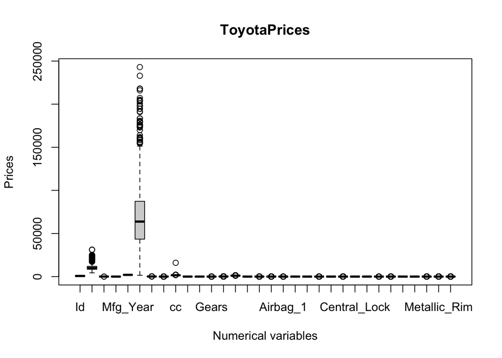

```r
boxplot(ToyotaPrices[unlist(lapply(ToyotaPrices,is.numeric))], xlab = "Numerical variables", ylab = "Prices", main = "ToyotaPrices")
```

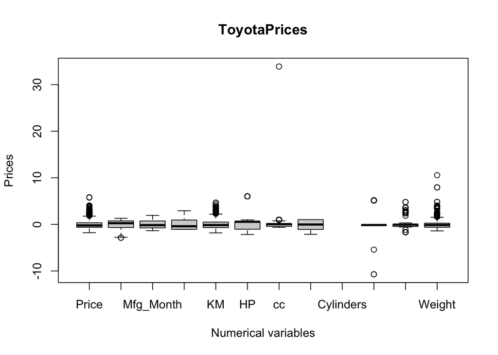

```r
boxplot(scale(ToyotaPrices[,c(2:7,9:14)]),xlab = "Numerical variables", ylab = "Prices", main = "ToyotaPrices")
```

Which variable(s) is (are) skewed?

```r
library(moments)
for (i in colnames(ToyotaPrices[,c(2:7,9:14)])){
  print(skewness(ToyotaPrices[i]))
}
```

```
##    Price
## 1.657621
##  Age_08_04
## -0.7969198
## Mfg_Month
## 0.2924234
##  Mfg_Year
## 0.8908595
##       KM
## 1.056933
##       HP
## 0.957827
##       cc
## 27.37522
##       Doors
## -0.06989202
## Cylinders
##       NaN
##    Gears
## 2.270118
## Quarterly_Tax
##      1.992244
##   Weight
## 3.005586
```

Which variable has the biggest (scaled) outliers?

```r
#cc value= 27.37522
```

2.Scatterplot of Price versus KM

Produce the scatterplot of Price versus the number of KM (kilometers) along with a loess smoother curve. Does the relation look like a line or a curve?

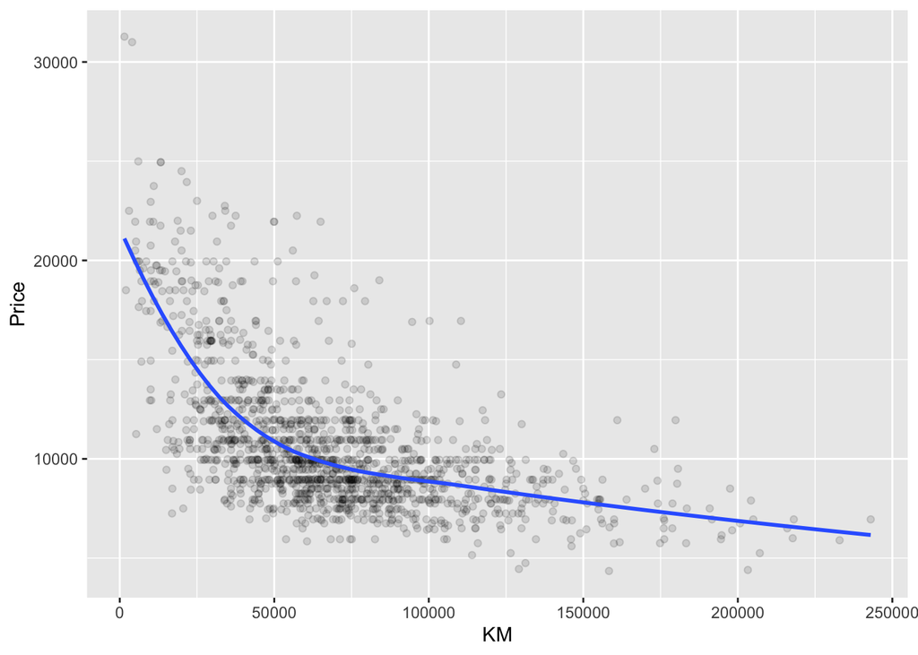

```r
library (ggplot2)
plot1 <- ggplot(ToyotaPrices) +
  aes(x=KM, y=Price) +
  geom_point(alpha = (1/8)) +
  geom_smooth(method = "loess", se = FALSE)

plot1
```

```r
#curve f(KM)= 1/KM
```

3.Box-Whisker plot of Price versus ABS

Produce side-by-side box-whisker plots of Price versus ABS (anti-lock breaks). Do automobiles with anti-locking breaks tend to have a higher price? Are there any outliers?

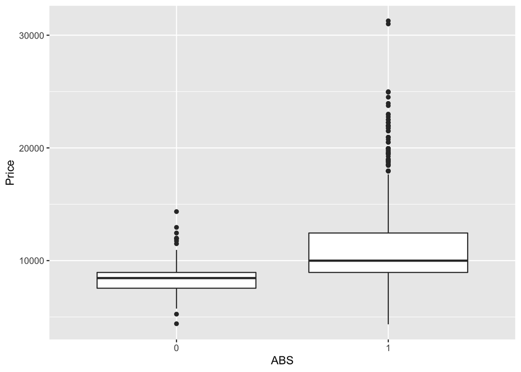

```r
ggplot(ToyotaPrices) +
  aes(x=ABS, y=Price) +
        geom_boxplot()
```

```r
#Prices higher with ABS
# Yes there are outliers
```

4.Correlation between Price and KM

Compute the correlation between Price and KM. Is it a strong or weak correlation? Is it positive or negative? If it is positive, what does it mean? Or. If it is negative, what does it mean?

```r
cor(ToyotaPrices$Price, ToyotaPrices$KM)
```

```
## [1] -0.5647259
```

```r
# medium negative
# As KM increase Price tends to go down, but other factors may intervene.
```

Subsetting Many times a dataset will have a great number of variables making analysis of a large dataset difficult. Here is a method to create a dataset that has a subset of the variables. The R command is subset (it is in the base package, base::subset). For example, to subset the variables Price, KM, Weight, Tow_Bar:

```r
myData <- subset(ToyotaPrices, select = c(Price, KM, Weight, Tow_Bar))
```

To eliminate a variable X1 from a dataframe, use the parameter select = -X1; or to eliminate two or more variables, e.g. X1 and X2, use select = -c(X1, X2). For example,

```r
myData_PKW <- subset(myData, select = -Tow_Bar)
```

To obtain more information about subsetting, use the command ?subset.

```r
# names(myData)
summary(myData)
```

```
##      Price             KM             Weight     Tow_Bar
##  Min.   : 4350   Min.   :  1500   Min.   :1000   NO :1027
##  1st Qu.: 8450   1st Qu.: 43426   1st Qu.:1040   YES: 398
##  Median : 9900   Median : 63792   Median :1065
##  Mean   :10675   Mean   : 69062   Mean   :1072
##  3rd Qu.:11900   3rd Qu.: 87358   3rd Qu.:1085
##  Max.   :31275   Max.   :243000   Max.   :1615
```

5.Price vs Tow_Bar

Obtain a side-by-side boxplot of Price versus Tow_Bar. How are the two boxplots different? Does Tow_Bar appear to predict Price? If it does, does having an optional Tow_Bar increase the price?

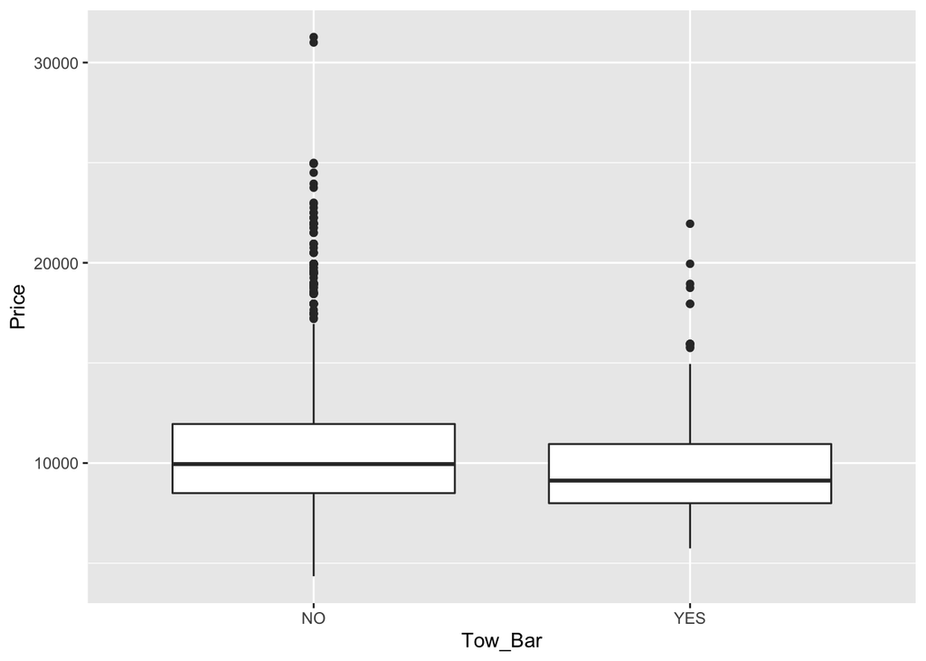

```r
myData$Tow_Bar <- factor(myData$Tow_Bar); levels(myData$Tow_Bar) <- c("NO", "YES")

plot1 <- ggplot(myData) +
  aes(x = Tow_Bar, y = Price) +
  geom_boxplot()
plot1
```

```r
#Optional Tow_Bar decrease the Price
```

6.KM vs Tow_Bar

Obtain side-by-side boxplots of KM versus Tow_Bar. How are the two boxplots different? Do autos with a tow bar have higher mileage?

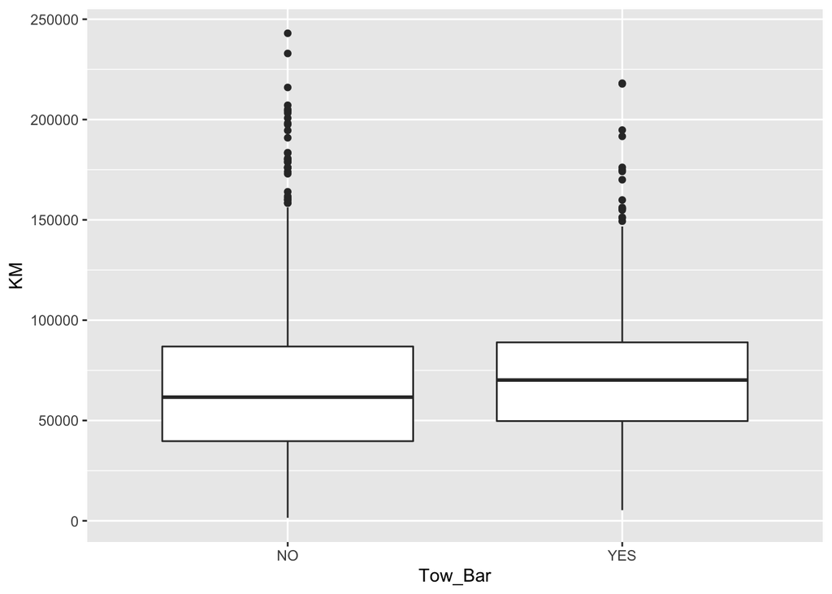

```r
plot2 <- ggplot(myData) +
  aes(x = Tow_Bar, y = KM) +
  geom_boxplot()
plot2
```

```r
#Cars with a Tow_bar has high mileage
```

7.The mystery deepens

Can you explain the direction of prediction of Tow_Bar on Price now that you see the connection of KM vs Tow_Bar? Produce a scatterplot with colors for the points indicating whether or not the auto has a Tow_Bar. Make the points opaque and add the smooth loess lines as well. What is going on here?

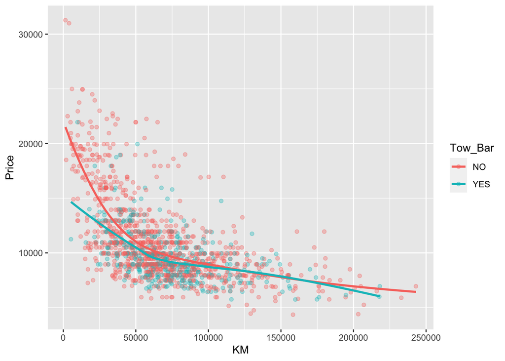

```r
plot3 <- ggplot(myData) +
  aes(x=KM, y=Price, color=Tow_Bar) +
  geom_point(alpha=I(1/3)) +
  geom_smooth(method = "loess", se=FALSE)
plot3
```